# 2016 and 2020 Election Analysis: Understanding Voting Changes

Adam Meyer

2023-08-08

# Load Libraries

```r
library(readr)
library(dplyr)
```

```r
library(ggplot2)
library(patchwork)
```

# Import Dataset

The datasets are from https://www.kaggle.com/datasets/etsc9287/2020-general-election-polls?resource=download

```r
county_statistics <- read_csv("C:/Users/apmey/OneDrive/Desktop/Election Data/county_statistics.csv")
```

```
## ──────────────────────────────────────────────────────── Delimiter: "," chr
## (2): county, state dbl (49): ...1, percentage16_Donald_Trump,
## percentage16_Hillary_Clinton, tot...
```

```r
#trump_biden_polls <- read_csv("C:/Users/apmey/OneDrive/Desktop/Election Data/trump_biden_polls.csv")

#trump_clinton_polls <- read_csv("C:/Users/apmey/OneDrive/Desktop/Election Data/trump_clinton_polls.csv")
```

# Data Profiling and Exploratory Data Analysis

```r
head(county_statistics)
```

```
## # A tibble: 6 × 51
##    ...1 county    state percen…¹ perce…² total…³ votes…⁴ votes…⁵ perce…⁶ perce…⁷
##   <dbl> <chr>     <chr>    <dbl>   <dbl>   <dbl>   <dbl>   <dbl>   <dbl>   <dbl>
## 1     0 Abbeville SC       0.629   0.346   10724    6742    3712   0.661   0.33
## 2     1 Acadia    LA       0.773   0.206   27386   21159    5638   0.795   0.191
## 3     2 Accomack  VA       0.545   0.428   15755    8582    6737   0.542   0.447
## 4     3 Ada       ID       0.479   0.387  195587   93748   75676   0.504   0.465
## 5     4 Adair     IA       0.653   0.3      3759    2456    1127   0.697   0.286
## 6     5 Adair     KY       0.806   0.161    8231    6637    1323   0.83    0.159
## # … with 41 more variables: total_votes20 <dbl>, votes20_Donald_Trump <dbl>,
## #   votes20_Joe_Biden <dbl>, lat <dbl>, long <dbl>, cases <dbl>, deaths <dbl>,
## #   TotalPop <dbl>, Men <dbl>, Women <dbl>, Hispanic <dbl>, White <dbl>,
## #   Black <dbl>, Native <dbl>, Asian <dbl>, Pacific <dbl>,
## #   VotingAgeCitizen <dbl>, Income <dbl>, IncomeErr <dbl>, IncomePerCap <dbl>,
## #   IncomePerCapErr <dbl>, Poverty <dbl>, ChildPoverty <dbl>,
## #   Professional <dbl>, Service <dbl>, Office <dbl>, Construction <dbl>, …
```

I can remove the first column “..1” becuase it serves no statitical purpose

```r
county_statistics = county_statistics[, -1]
```

### Information on variables

NOTE: This is important for creating new variables from existing varibales

```r
str(county_statistics)
```

```
## tibble [4,867 × 50] (S3: tbl_df/tbl/data.frame)
##  $ county                      : chr [1:4867] "Abbeville" "Acadia" "Accomack" "Ada" ...
##  $ state                       : chr [1:4867] "SC" "LA" "VA" "ID" ...
##  $ percentage16_Donald_Trump   : num [1:4867] 0.629 0.773 0.545 0.479 0.653 0.806 0.594 0.735 0.421 0.669 ...
##  $ percentage16_Hillary_Clinton: num [1:4867] 0.346 0.206 0.428 0.387 0.3 0.161 0.345 0.212 0.494 0.271 ...
##  $ total_votes16               : num [1:4867] 10724 27386 15755 195587 3759 ...
##  $ votes16_Donald_Trump        : num [1:4867] 6742 21159 8582 93748 2456 ...
##  $ votes16_Hillary_Clinton     : num [1:4867] 3712 5638 6737 75676 1127 ...
##  $ percentage20_Donald_Trump   : num [1:4867] 0.661 0.795 0.542 0.504 0.697 0.83 0.618 0.786 0.404 0.708 ...
##  $ percentage20_Joe_Biden      : num [1:4867] 0.33 0.191 0.447 0.465 0.286 0.159 0.358 0.195 0.567 0.273 ...
##  $ total_votes20               : num [1:4867] 12433 28425 16938 259389 4183 ...
##  $ votes20_Donald_Trump        : num [1:4867] 8215 22596 9172 130699 2917 ...
##  $ votes20_Joe_Biden           : num [1:4867] 4101 5443 7578 120539 1197 ...
##  $ lat                         : num [1:4867] 34.2 30.3 37.8 43.5 41.3 ...
##  $ long                        : num [1:4867] -82.5 -92.4 -75.6 -116.2 -94.5 ...
```

[output cut: 36 more lines]

### Checking for missing values

```r
missing_counts <- colSums(is.na(county_statistics))

print(missing_counts)
```

```
##                       county                        state
##                            0                            0
##    percentage16_Donald_Trump percentage16_Hillary_Clinton
##                         1756                         1756
##                total_votes16         votes16_Donald_Trump
##                         1756                         1756
##      votes16_Hillary_Clinton    percentage20_Donald_Trump
##                         1756                          377
##       percentage20_Joe_Biden                total_votes20
##                          377                          234
##         votes20_Donald_Trump            votes20_Joe_Biden
##                          234                          234
##                          lat                         long
##                         1615                         1615
##                        cases                       deaths
##                         1615                         1615
##                     TotalPop                          Men
##                         1725                         1725
##                        Women                     Hispanic
##                         1725                         1725
##                        White                        Black
##                         1725                         1725
##                       Native                        Asian
##                         1725                         1725
##                      Pacific             VotingAgeCitizen
##                         1725                         1725
##                       Income                    IncomeErr
##                         1725                         1725
##                 IncomePerCap              IncomePerCapErr
##                         1725                         1725
##                      Poverty                 ChildPoverty
##                         1725                         1726
##                 Professional                      Service
##                         1725                         1725
##                       Office                 Construction
##                         1725                         1725
##                   Production                        Drive
##                         1725                         1725
##                      Carpool                      Transit
##                         1725                         1725
##                         Walk                  OtherTransp
##                         1725                         1725
##                   WorkAtHome                  MeanCommute
##                         1725                         1725
##                     Employed                  PrivateWork
##                         1725                         1725
##                   PublicWork                 SelfEmployed
##                         1725                         1725
##                   FamilyWork                 Unemployment
##                         1725                         1725
```

Sub dataset with rows that contain missing data

```r
NA_df <- county_statistics[!complete.cases(county_statistics), ]

print(NA_df)
```

```
## # A tibble: 1,821 × 50
##    county  state perce…¹ perce…² total…³ votes…⁴ votes…⁵ perce…⁶ perce…⁷ total…⁸
##    <chr>   <chr>   <dbl>   <dbl>   <dbl>   <dbl>   <dbl>   <dbl>   <dbl>   <dbl>
##  1 Alexan… VA      0.178   0.768   74384   13241   57147   0.178   0.81    81806
##  2 Andros… ME      0.509   0.415   55340   28189   22975  NA      NA          NA
##  3 Aroost… ME      0.555   0.383   34963   19419   13377  NA      NA          NA
##  4 Baltim… MD      0.109   0.854  208980   22726  178562   0.108   0.877  220296
##  5 Belknap NH      0.56    0.392   34497   19315   13517  NA      NA          NA
##  6 Berksh… MA      0.26    0.675   64507   16799   43540  NA      NA          NA
##  7 Bristol MA      0.426   0.519  246068  104775  127619  NA      NA          NA
##  8 Bristo… VA      0.701   0.263    6966    4884    1832   0.687   0.297    7785
##  9 Buena … VA      0.598   0.289    2395    1432     693   0.662   0.293    2815
## 10 Caledo… VT      0.427   0.497   12966    5533    6445  NA      NA          NA
## # … with 1,811 more rows, 40 more variables: votes20_Donald_Trump <dbl>,
## #   votes20_Joe_Biden <dbl>, lat <dbl>, long <dbl>, cases <dbl>, deaths <dbl>,
## #   TotalPop <dbl>, Men <dbl>, Women <dbl>, Hispanic <dbl>, White <dbl>,
## #   Black <dbl>, Native <dbl>, Asian <dbl>, Pacific <dbl>,
## #   VotingAgeCitizen <dbl>, Income <dbl>, IncomeErr <dbl>, IncomePerCap <dbl>,
## #   IncomePerCapErr <dbl>, Poverty <dbl>, ChildPoverty <dbl>,
## #   Professional <dbl>, Service <dbl>, Office <dbl>, Construction <dbl>, …
```

### Conclusion: There are a lot of counties that don’t have data from the 2016 election or the 2020 election. Since we care looking at the change over the two time periods, I will drop the missing data because I can’t make any conclusion about how they changed.

```r
county_statistics <- na.omit(county_statistics)
```

```r
head(county_statistics)
```

```
## # A tibble: 6 × 50
##   county   state perce…¹ perce…² total…³ votes…⁴ votes…⁵ perce…⁶ perce…⁷ total…⁸
##   <chr>    <chr>   <dbl>   <dbl>   <dbl>   <dbl>   <dbl>   <dbl>   <dbl>   <dbl>
## 1 Abbevil… SC      0.629   0.346   10724    6742    3712   0.661   0.33    12433
## 2 Acadia   LA      0.773   0.206   27386   21159    5638   0.795   0.191   28425
## 3 Accomack VA      0.545   0.428   15755    8582    6737   0.542   0.447   16938
## 4 Ada      ID      0.479   0.387  195587   93748   75676   0.504   0.465  259389
## 5 Adair    IA      0.653   0.3      3759    2456    1127   0.697   0.286    4183
## 6 Adair    KY      0.806   0.161    8231    6637    1323   0.83    0.159    8766
## # … with 40 more variables: votes20_Donald_Trump <dbl>,
## #   votes20_Joe_Biden <dbl>, lat <dbl>, long <dbl>, cases <dbl>, deaths <dbl>,
## #   TotalPop <dbl>, Men <dbl>, Women <dbl>, Hispanic <dbl>, White <dbl>,
## #   Black <dbl>, Native <dbl>, Asian <dbl>, Pacific <dbl>,
## #   VotingAgeCitizen <dbl>, Income <dbl>, IncomeErr <dbl>, IncomePerCap <dbl>,
## #   IncomePerCapErr <dbl>, Poverty <dbl>, ChildPoverty <dbl>,
## #   Professional <dbl>, Service <dbl>, Office <dbl>, Construction <dbl>, …
```

## Understanding Voting Changes

Creating Maps

```r
us_2020_map <- ggplot(county_statistics, aes(x = long, y = lat, size = total_votes20, color = percentage20_Joe_Biden)) +
  geom_point(shape = 16) +
  scale_color_distiller(palette = "RdBu", direction = 1) +
  labs(title = "The 2020 Election (Red = More Republican; Blue = More Democratic)",
       x = "Longitude", y = "Latitude",
       size = "# of Votes", color = "Biden's Percentage") +
  theme_minimal() +
  theme(legend.position = "bottom")

us_2016_map <- ggplot(county_statistics, aes(x = long, y = lat, size = total_votes16, color = percentage16_Donald_Trump)) +
  geom_point(shape = 16) +
  scale_color_distiller(palette = "RdBu", direction = -1) +
  labs(title = "The 2016 Election (Red = More Republican; Blue = More Democratic)",
       x = "Longitude", y = "Latitude",
       size = "# of Votes", color = "Trump's Percentage") +
  theme_minimal() +
  theme(legend.position = "bottom")
```

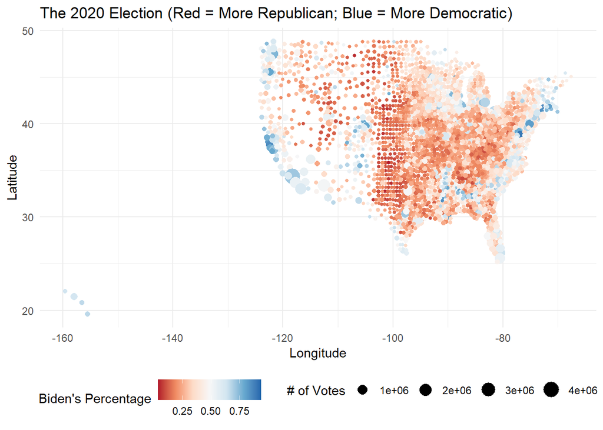

```r
us_2020_map
```

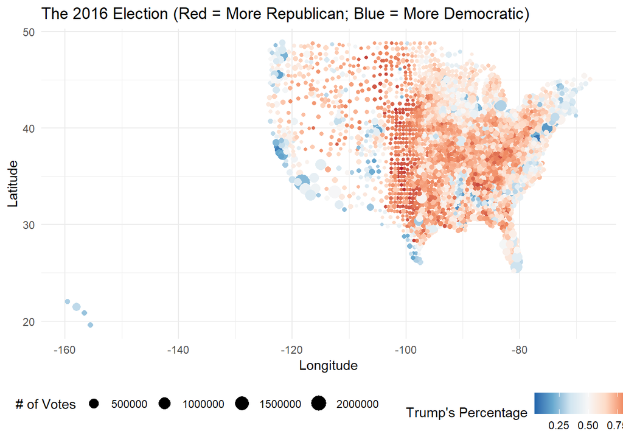

```r
us_2016_map
```

Based on the two maps, we see differences in voting percentages in certain counties. Additionally, there is also change in the value for the number of vote scale, meaning there seems to be an increase in amount of voters in some county from 2016 to 2020

First I want to see the map without Hawaii included, since it changes the scales of the longitute and latitude.

```r
df_mainland <- county_statistics[!(county_statistics$state %in% c("AK", "HI")), ]

# Create the scatterplot with custom legend labels
ml_2020_map <- ggplot(df_mainland, aes(x = long, y = lat, size = total_votes20, color = percentage20_Joe_Biden)) +
  geom_point(shape = 16) +
  scale_color_distiller(palette = "RdBu", direction = 1) +
  labs(title = "The 2020 Election (Red = More Republican; Blue = More Democratic)",
       x = "Longitude", y = "Latitude",
       size = "# of votes", color = "Biden's Percentage") +  # Customizing the legend labels
  theme_minimal() +
  theme(legend.position = "bottom")

ml_2016_map <- ggplot(df_mainland, aes(x = long, y = lat, size = total_votes16, color = percentage16_Donald_Trump)) +
  geom_point(shape = 16) +
  scale_color_distiller(palette = "RdBu", direction = -1) +
  labs(title = "The 2016 Election (Red = More Republican; Blue = More Democratic)",
       x = "Longitude", y = "Latitude",
       size = "# of Votes", color = "Trump's Percentage") +
  theme_minimal() +
  theme(legend.position = "bottom")
```

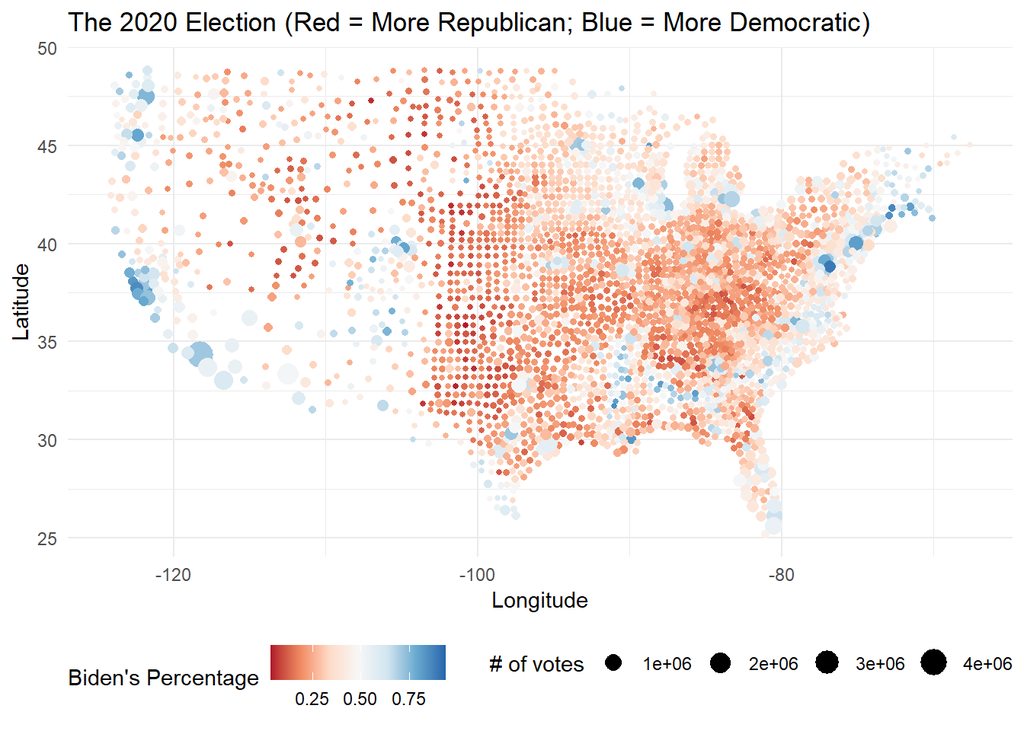

```r
ml_2020_map
```

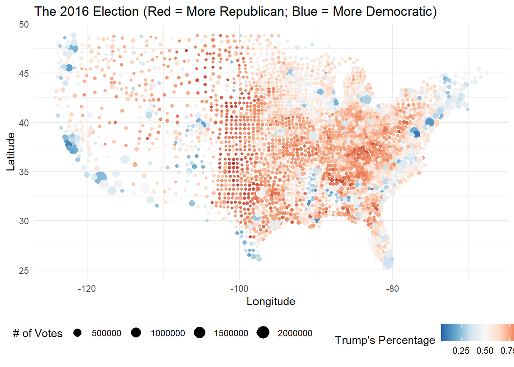

```r
ml_2016_map
```

Based on the closer view, the Utah area seemed to become increasingly in favor of Trump in the 2020 election. But it is harder to see increases in democratic favor. To see these changes we must create some new varibales.

```r
df_mainland <- df_mainland %>%
  mutate(trump_pct_change = percentage20_Donald_Trump - percentage16_Donald_Trump) %>%
  mutate(dem_pct_change = percentage20_Joe_Biden - percentage16_Hillary_Clinton)
```

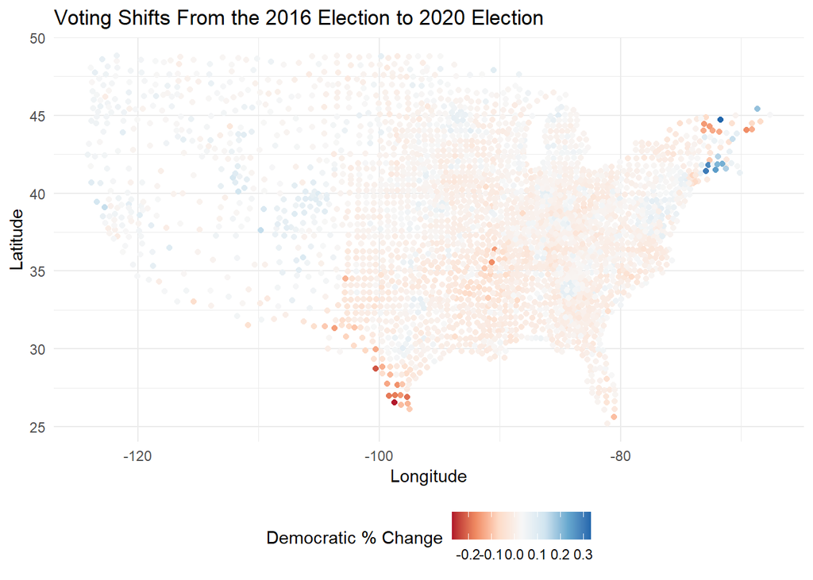

```r
dem_change_map <- ggplot(df_mainland, aes(x = long, y = lat, color = dem_pct_change)) +
  geom_point(shape = 16) +
  scale_color_distiller(palette = "RdBu", direction = 1) +
  labs(title = "Voting Shifts From the 2016 Election to 2020 Election",
       x = "Longitude", y = "Latitude",
       color = "Democratic % Change") +
  theme_minimal() +
  theme(legend.position = "bottom")

dem_change_map
```

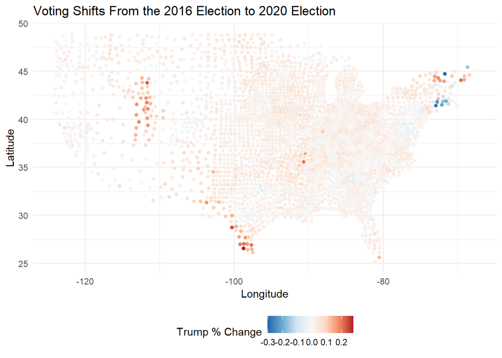

```r
trump_change_map <- ggplot(df_mainland, aes(x = long, y = lat, color = trump_pct_change)) +
  geom_point(shape = 16) +
  scale_color_distiller(palette = "RdBu", direction = -1) +
  labs(title = "Voting Shifts From the 2016 Election to 2020 Election",
       x = "Longitude", y = "Latitude",
       color = "Trump % Change") +
  theme_minimal() +
  theme(legend.position = "bottom")

trump_change_map
```

Based on these two maps, Trump gained support on the Southern Boarder of Texas from Demacrats, while he gain voters in the Utah/Idaho/Nevada areas from non Repulican/Democrat voters, because Biden got a similar percentage than Clinton had.